# Coursework Report

*N* removed NAs: 3

*N* removed typo: 1

*N* removed <18: 23

*N* total clean: 123

| Group | *N* | *M*<sub>age</sub> | *M*<sub>rating</sub> |
| --- | --- | --- | --- |
| Control | 68 | 20.94 | 5.36 |
| Experim | 55 | 21.04 | 6.50 |

**Main analysis results**

*t*(121) = -7.07, *p* < .001

[interactive chart not shown]

[figure not shown]

[interactive chart not shown]

# Coursework Report

Analysing Data, Spring 2020

# Methods

## Participants

Table 1 below shows the descriptives of the participants by the condition.

Table 1. Condition descriptive statistic

| Condition | Participants | Percentage | Mean age | SD age |
| --- | --- | --- | --- | --- |
| White | 68 | 55.28 | 20.94 | 2.59 |
| Red | 55 | 44.72 | 21.04 | 2.17 |

## Design

The research question for Study 1 in the design is looking at whether the colour red increases women’s attraction towards men when compared to white. The conceptual hypothesis is that the colour red does enhance women’s attraction towards men. (Elliot et al 2010)

The operationalised variables I will use in my analysis include:

- **Id_code** which is the unique participant id, is a factor with 150 levels, using different mixtures of four letters to create it.
- **Years** which is a continuous variable from 18 years to 27 years.
- **Group** which is a factor with 2 levels, the experimental conditions which are white and red.
- **Item_1,** **item_2** and **item_3** which are all ratings which are numeric, with the lowest possible value being 1 and the highest being 9.
  - A high score shows a high rating of perceived attractiveness, which is measured using the three questions (items).

The operational hypothesis that the data hopes to answer is; does looking at a moderately attractive man on different coloured frames influence the mean rating of attractiveness on the perceived attractiveness scale? (Elliot et al 2010)

To analysis this statement I will be creating a composite score of the three ratings of perceived attractiveness, a mean plot and then a t-test to see if it is statistically significant.

# Results

I investigated whether females gave different ratings of attractiveness when presented with a man’s picture with a white frame or with a red frame. The mean score for the white condition was 5.36 and the mean score for the red condition was 6.5. Therefore, my results show that the mean attractiveness for the red condition was higher than the white condition, this shown in my means plot below.

Results from my independent *t*-test show (*M*<sub>diff</sub> = -1.1372549, 95% CI [-1.46, -0.82], *t* (121) = -7.07, *p* = <.001).

My value of t is quite big, suggesting that the difference in the means is significantly different. Since p = <.001 which is less than 0.05 (chosen probability level), we can conclude that the null hypothesis should be rejected and accept the alternative hypothesis. The confidence intervals also show this, as they are close to 0 but both lower than 0, therefore the true difference in means is not 0.

Therefore, this shows that in our sample, due to their being a difference between the mean ratings in the two different conditions, and a significant t-test, we can interpret this as meaning that colour does in fact influence attractiveness.

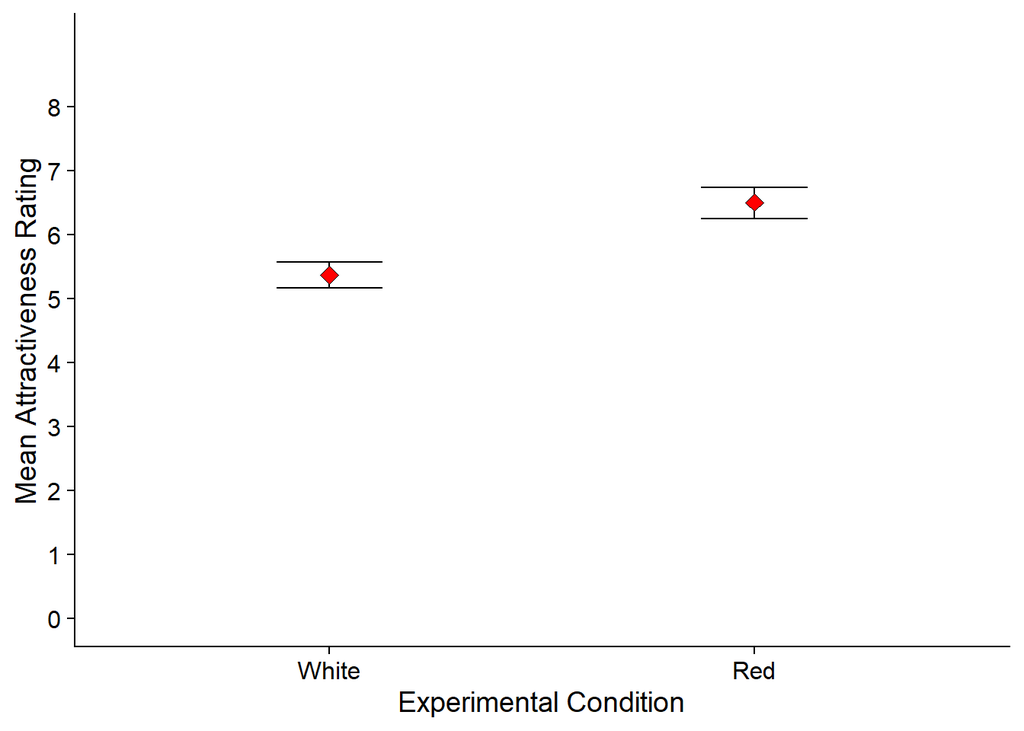

Figure 1. The mean attractiveness ratings for two experimental conditions

# Discussion

My results suggest that the difference in mean values for the two conditions was significant. Therefore, this supports our hypothesis that the colour red on men does influence attractiveness ratings of women.

The results from the original study by Elliot et al (2010) also supported their hypothesis and therefore it was concluded from their study that colour does influence attraction ratings.

I found a larger value of t compared to the original study, and a larger difference in the means, suggesting that the effect I found was larger than in the original study, even though they both found significant results.

For the effect I am investigating this shows that it could be a real effect, if the study is able to be replicated so many times. However, in research by Francis (2013) they suggested that publication bias may be involved in Elliot et al’s (2010) experiments.

Francis (2013) found that the experiments did not have enough power which means that there should have been less experiments rejecting the null hypothesis and finding the effect to be true. This is due to the fact that the experiments had small sample sizes and therefore little power and should not have be able to reject the null hypothesis so many times. The test of publication bias by Ionnidias and Trikalinos (2007) found that Elliot et al’s (2010) studies showed strong evidence of bias (however the test was described as “exploratory” and should not be completely trusted). Therefore, it should not have been possible for all of the experiments to find that colour has an effect on attractiveness, sexual desirability or status.

The effect of colour and attractiveness has also been found by S.C Roberts et al (2010), they showed that seeing a man wearing a red shirt increased the women’s rating of attractiveness. Their experiment found a stronger effect than Elliot et al’s (2010) experiments, both of the experiments mirror the results that I found for the replication of Study 1 of Elliot’s experiment.

A limitation in the experiment is sample size, which was addressed by Elliot and Maier (2013) and they went on to replicate their own experiment with a larger sample. They found a similar result, however even though it was not significant, it was in the same direction as their original studies. Sample size impacts the results of the experiment quite a lot and could be seen as a large issue, with a bigger sample size the experiment is more likely to provide accurate mean values compared to a small sample.

The experiment can teach us that there is some sort of impact of colour on attractiveness, however it needs to be investigated further to be able to certainly say it has an effect. Publication bias in Elliot’s study means that it is hard to take their results as meaning anything. In their samples they found that there was an effect, this does not mean that we are able to generalise this to the whole population, especially if not all of the experiments are reliable.

In the wider scientific context, Francis (2013) claimed that publication bias not only was in Elliot’s (2010) studies, but also occurred throughout experimental psychology. However, Elliot and Maier (2013) argue that this should not just be applied to their research and that a meta-analysis should be looked at. The experiments should be repeated, and null hypothesis findings should also be reported as well as the experiments that are able to reject the null hypothesis. However, just because there may be publication bias it does not mean that the effect found is not true.

Based on my results and the replication of the study, I believe that it does show a real effect. The fact that Elliot et al (2010) also consistently found this effect should be acknowledged, however maybe should not be taken to be a completely significant effect due to the possible publication bias. The data that I analysed was from a larger sample that the original experiment, therefore the mean values would have been more reliable. The effect that I found was significant, therefore based on my research and considering the limitations I think the effect is real. However there is still some doubt surrounding the original experiment and whether it should be seen valid.

Further experiments should be conducted, as Francis tried to discredit Elliot’s studies (2010). There should be more attempts to replicate it, as well as looking at difference ways of testing the effect. For example, they could look at whether the colour of the environment impacts the attractiveness ratings that men receive. They would be put in different coloured rooms including a red one and then look at black and white photos of men and rate them with the same scale. Therefore, this would look at the hypothesis in a different way with some of the same aspects of the original experiments.

In conclusion, my results were found to be significant with a 0.05 probability level. This meant that I was able to reject the null hypothesis and state that colour does in fact have an effect on the mean attractiveness ratings of men. These results were similar to the original studies’ findings of Elliot et al (2010), and I found a similar pattern and direction of results, the difference being that my study had a much larger sample size which mean the mean scores were more reliable. In this discussion, I addressed the problem of publication bias of Elliot et al’s studies (2010) which put some doubt on their conclusions. However, considering that the results that I found support the original study, I conclude that the effect of colour on attractiveness is real.

# References

Elliot, A., & Maier, M. (2013). The Red-Attractiveness Effect, Applying the Ionnidis and Trikalinos (2007b) test, and the Broader Scientific Context: A Reply to Francis 2013. *Journal of Experimental Psychology: General*, Vol 142, No 1, 297-300.

Elliot, A. J., Greitmeyer, T., Gramzow, R. H., Kayser, D. N., Lichtenfeld, S., Maier, M. A., & Liu, H. (2010). Red, rank, and romance in women viewing men. *Journal of Experimental Psychology: General*, 139, 399 – 417. doi:10.1037/a0019689

Francis, G. (2013). Publication bias in “Red, Rank and Romance in Women Viewing Men” by Elliot et al. (2010) *Journal of Experimental Psychology: General*, Vol 142, No 1, 292-296.

Ioannidis, J. P. A., & Trikalinos, T. A. (2007). An exploratory test for an excess of significant findings. *Clinical Trials*, 4, 245–253. doi:10.1177/ 1740774507079441

Roberts, S. C., Owen, R. C., & Havlicek, J. (2010). Distinguishing between perceiver and wearer effects in clothing colour-associated attributions. *Evolutionary Psychology*, 8, 350–364.